###1. How many breweries are present in each state

```r
hello_breweries = read.csv("Breweries.csv")
hello_beers = read.csv("Beers.csv")
dim(hello_breweries)
```

```
## [1] 558   4
```

```r
head(hello_breweries)
```

```
##   Brew_ID                      Name          City State
## 1       1        NorthGate Brewing    Minneapolis    MN
## 2       2 Against the Grain Brewery    Louisville    KY
## 3       3  Jack's Abby Craft Lagers    Framingham    MA
## 4       4 Mike Hess Brewing Company     San Diego    CA
## 5       5   Fort Point Beer Company San Francisco    CA
## 6       6     COAST Brewing Company    Charleston    SC
```

```r
dim(hello_beers)
```

```
## [1] 2410    7
```

```r
head(hello_beers)
```

```
##                  Name Beer_ID   ABV IBU Brewery_id
## 1            Pub Beer    1436 0.050  NA        409
## 2         Devil's Cup    2265 0.066  NA        178
## 3 Rise of the Phoenix    2264 0.071  NA        178
## 4            Sinister    2263 0.090  NA        178
## 5       Sex and Candy    2262 0.075  NA        178
## 6        Black Exodus    2261 0.077  NA        178
##                            Style Ounces
## 1            American Pale Lager     12
## 2        American Pale Ale (APA)     12
## 3                   American IPA     12
## 4 American Double / Imperial IPA     12
## 5                   American IPA     12
## 6                  Oatmeal Stout     12
```

```r
#by states
hello1=table(hello_breweries$State)
hello1
```

```
##
##  AK  AL  AR  AZ  CA  CO  CT  DC  DE  FL  GA  HI  IA  ID  IL  IN  KS  KY  LA  MA
##   7   3   2  11  39  47   8   1   2  15   7   4   5   5  18  22   3   4   5  23
##  MD  ME  MI  MN  MO  MS  MT  NC  ND  NE  NH  NJ  NM  NV  NY  OH  OK  OR  PA  RI
##   7   9  32  12   9   2   9  19   1   5   3   3   4   2  16  15   6  29  25   5
##  SC  SD  TN  TX  UT  VA  VT  WA  WI  WV  WY
##   4   1   3  28   4  16  10  23  20   1   4
```

```r
dim(hello1)
```

```
## [1] 51
```

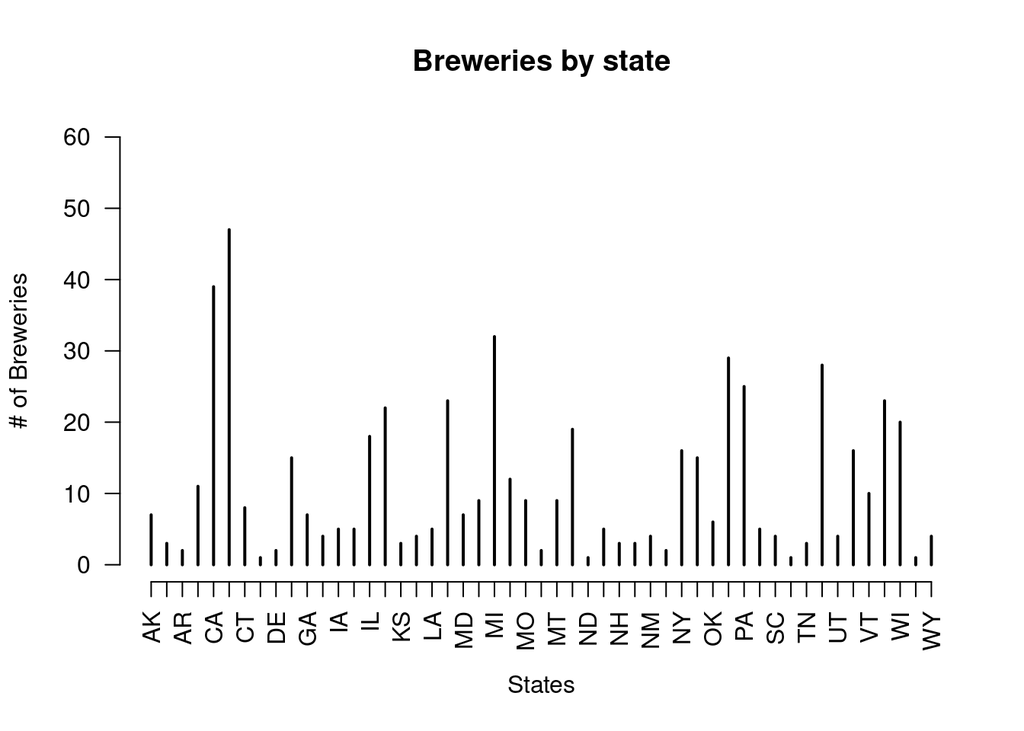

```r
plot(hello1,main = "Breweries by state",xlab = "States", ylab = "# of Breweries",ylim=c(0,60),cex.axis = 1, las=2)
```

##2. Merge beer data with the breweries data. Print the first 6 observations and the last six observations to check the merged file. (RMD only, this does not need to be included in the presentation or the deck.)

```r
hello_merge = merge(hello_breweries,hello_beers,by.x = "Brew_ID", by.y = "Brewery_id")
dim(hello_merge)
```

```
## [1] 2410   10
```

```r
head(hello_merge)
```

```
##   Brew_ID             Name.x        City State        Name.y Beer_ID   ABV IBU
## 1       1 NorthGate Brewing  Minneapolis    MN       Pumpion    2689 0.060  38
## 2       1 NorthGate Brewing  Minneapolis    MN    Stronghold    2688 0.060  25
## 3       1 NorthGate Brewing  Minneapolis    MN   Parapet ESB    2687 0.056  47
## 4       1 NorthGate Brewing  Minneapolis    MN  Get Together    2692 0.045  50
## 5       1 NorthGate Brewing  Minneapolis    MN Maggie's Leap    2691 0.049  26
## 6       1 NorthGate Brewing  Minneapolis    MN    Wall's End    2690 0.048  19
##                                 Style Ounces
## 1                         Pumpkin Ale     16
## 2                     American Porter     16
## 3 Extra Special / Strong Bitter (ESB)     16
## 4                        American IPA     16
## 5                  Milk / Sweet Stout     16
## 6                   English Brown Ale     16
```

```r
filter(hello_breweries, "Brew_ID" == "1")
```

[output not shown]

[output cut: 548 more lines]

```r
filter(hello_beers, "Beer_ID" == "2689")
```

[output not shown]

[output cut: 2400 more lines]

```r
tail(hello_merge)
```

```
##      Brew_ID                        Name.x          City State
## 2405     556         Ukiah Brewing Company         Ukiah    CA
## 2406     557       Butternuts Beer and Ale Garrattsville    NY
## 2407     557       Butternuts Beer and Ale Garrattsville    NY
## 2408     557       Butternuts Beer and Ale Garrattsville    NY
## 2409     557       Butternuts Beer and Ale Garrattsville    NY
## 2410     558 Sleeping Lady Brewing Company     Anchorage    AK
##                         Name.y Beer_ID   ABV IBU                   Style Ounces
## 2405             Pilsner Ukiah      98 0.055  NA         German Pilsener     12
## 2406         Porkslap Pale Ale      49 0.043  NA American Pale Ale (APA)     12
## 2407           Snapperhead IPA      51 0.068  NA            American IPA     12
## 2408         Moo Thunder Stout      50 0.049  NA      Milk / Sweet Stout     12
## 2409  Heinnieweisse Weissebier      52 0.049  NA              Hefeweizen     12
## 2410 Urban Wilderness Pale Ale      30 0.049  NA        English Pale Ale     12
```

```r
filter(hello_breweries, "Brew_ID" == "558")
```

[output not shown]

[output cut: 548 more lines]

```r
filter(hello_beers, "Beer_ID" == "30")
```

[output not shown]

[output cut: 2400 more lines]

##3. Address the missing values in each column.

```r
hello_NA = hello_merge[!complete.cases(hello_merge),]
dim(hello_NA)
```

```
## [1] 1005   10
```

```r
head(hello_NA)
```

```
##    Brew_ID                    Name.x       City State          Name.y Beer_ID
## 19       2 Against the Grain Brewery Louisville    KY  Kamen Knuddeln    2676
## 35       6     COAST Brewing Company Charleston    SC        Rye Knot    2656
## 36       6     COAST Brewing Company Charleston    SC        Dead Arm    2655
## 37       6     COAST Brewing Company Charleston    SC 32°/50° Kölsch     2654
## 38       6     COAST Brewing Company Charleston    SC      Blackbeard    2657
## 39       6     COAST Brewing Company Charleston    SC        Boy King    2652
##      ABV IBU                            Style Ounces
## 19 0.065  NA                American Wild Ale     16
## 35 0.062  NA               American Brown Ale     12
## 36 0.060  NA          American Pale Ale (APA)     12
## 37 0.048  NA                           Kölsch     16
## 38 0.093  NA American Double / Imperial Stout     12
## 39 0.097  NA   American Double / Imperial IPA     16
```

```r
hello_NNA = hello_merge[complete.cases(hello_merge),]
dim(hello_NNA)
```

```
## [1] 1405   10
```

```r
head(hello_NNA)
```

```
##   Brew_ID             Name.x        City State        Name.y Beer_ID   ABV IBU
## 1       1 NorthGate Brewing  Minneapolis    MN       Pumpion    2689 0.060  38
## 2       1 NorthGate Brewing  Minneapolis    MN    Stronghold    2688 0.060  25
## 3       1 NorthGate Brewing  Minneapolis    MN   Parapet ESB    2687 0.056  47
## 4       1 NorthGate Brewing  Minneapolis    MN  Get Together    2692 0.045  50
## 5       1 NorthGate Brewing  Minneapolis    MN Maggie's Leap    2691 0.049  26
## 6       1 NorthGate Brewing  Minneapolis    MN    Wall's End    2690 0.048  19
##                                 Style Ounces
## 1                         Pumpkin Ale     16
## 2                     American Porter     16
## 3 Extra Special / Strong Bitter (ESB)     16
## 4                        American IPA     16
## 5                  Milk / Sweet Stout     16
## 6                   English Brown Ale     16
```

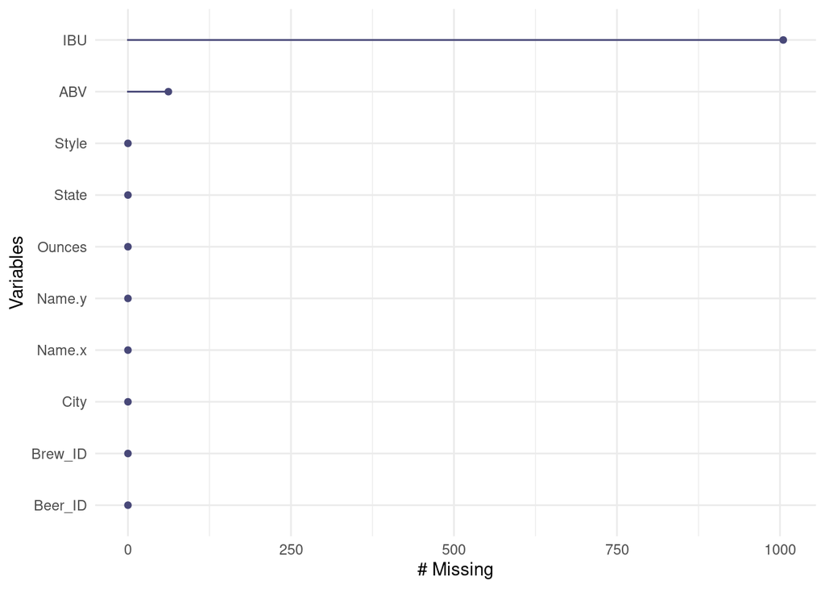

```r
library(naniar)
gg_miss_var(hello_merge)
```

##4. Compute the median alcohol content and international bitterness unit for each state. Plot a bar chart to compare.

```r
library(dplyr)
dplyr::summarize
```

```
## function (.data, ..., .groups = NULL)
## {
##     UseMethod("summarise")
## }
## <bytecode: 0x5641216c7a20>
## <environment: namespace:dplyr>
```

```r
hello1 <- hello_merge %>% group_by(State) %>% summarize(medianABV = median(ABV,na.rm = TRUE), count = n()) %>% arrange(medianABV)
print(hello1)
```

```
## # A tibble: 51 × 3
##    State medianABV count
##    <chr>     <dbl> <int>
##  1 " UT"     0.04     26
##  2 " NJ"     0.046     8
##  3 " KS"     0.05     23
##  4 " ND"     0.05      3
##  5 " WY"     0.05     15
##  6 " ME"     0.051    27
##  7 " AR"     0.052     5
##  8 " LA"     0.052    19
##  9 " MO"     0.052    42
## 10 " WI"     0.052    87
## # … with 41 more rows
```

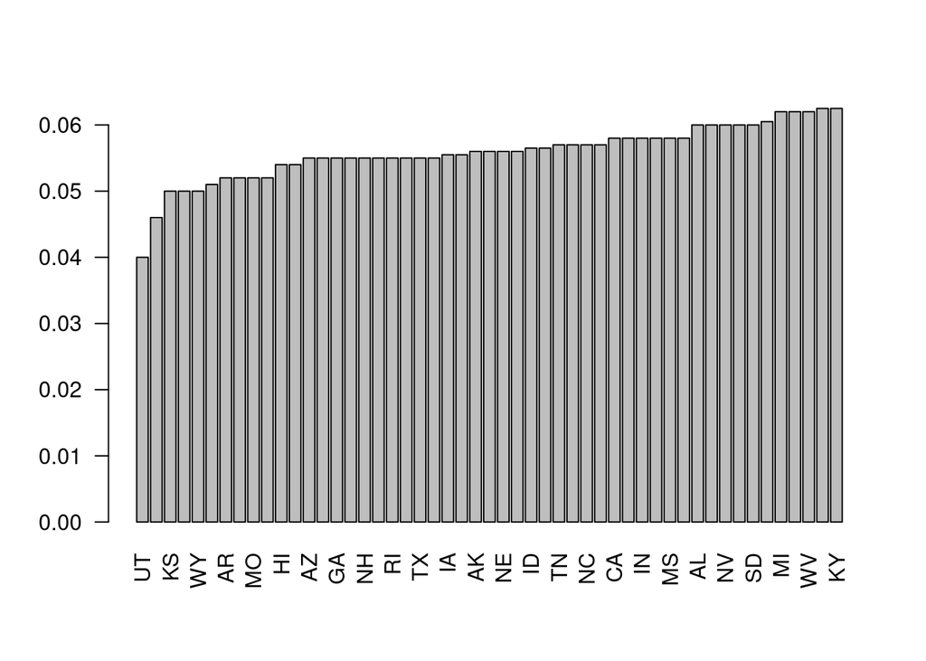

```r
barplot(hello1$medianABV, names.arg = hello1$State, las=2)
```

```r
hello2 <- hello_merge %>% group_by(State) %>% summarize(medianIBU = median(IBU,na.rm = TRUE), count = n()) %>% arrange(medianIBU)
print(hello2)
```

```
## # A tibble: 51 × 3
##    State medianIBU count
##    <chr>     <dbl> <int>
##  1 " WI"      19      87
##  2 " KS"      20      23
##  3 " AZ"      20.5    47
##  4 " WY"      21      15
##  5 " HI"      22.5    27
##  6 " MO"      24      42
##  7 " RI"      24      27
##  8 " IA"      26      30
##  9 " CT"      29      27
## 10 " MD"      29      21
## # … with 41 more rows
```

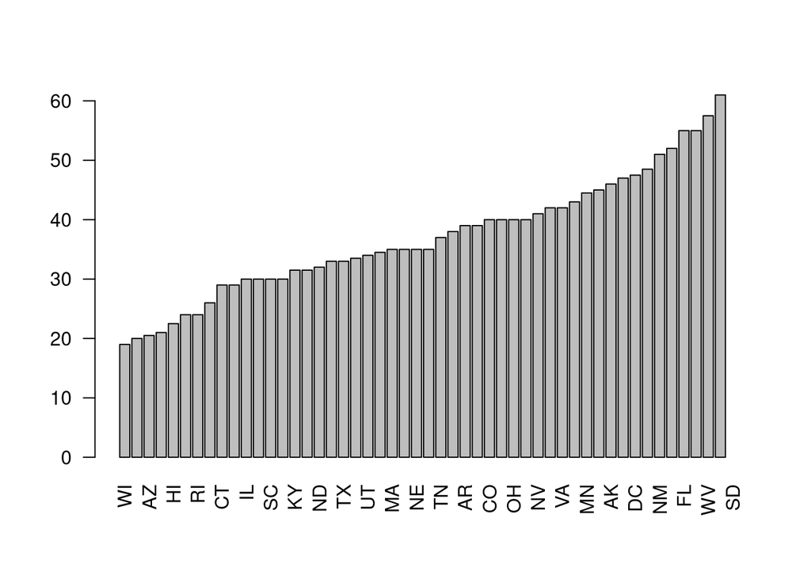

```r
barplot(hello2$medianIBU, names.arg = hello2$State, las=2)
```

##5. Which state has the maximum alcoholic (ABV) beer? Which state has the most bitter (IBU) beer?

```r
hello_ABV <- hello_merge %>% group_by(State)%>%summarize(max_alc=max(ABV,na.rm=TRUE)) %>% arrange(desc(max_alc))
hello_IBU <- hello_merge %>% group_by(State)%>%summarize(max_ibu=max(IBU,na.rm=TRUE)) %>% arrange(max_ibu)
hello_ABV
```

```
## # A tibble: 51 × 2
##    State max_alc
##    <chr>   <dbl>
##  1 " CO"   0.128
##  2 " KY"   0.125
##  3 " IN"   0.12
##  4 " NY"   0.1
##  5 " CA"   0.099
##  6 " ID"   0.099
##  7 " MA"   0.099
##  8 " ME"   0.099
##  9 " MI"   0.099
## 10 " MN"   0.099
## # … with 41 more rows
```

```r
hello_IBU
```

```
## # A tibble: 51 × 2
##    State max_ibu
##    <chr>   <dbl>
##  1 " SD"    -Inf
##  2 " AR"      39
##  3 " DE"      52
##  4 " LA"      60
##  5 " TN"      61
##  6 " GA"      65
##  7 " NE"      65
##  8 " SC"      65
##  9 " ME"      70
## 10 " ND"      70
## # … with 41 more rows
```

6. Comment on the summary statistics and distribution of the ABV variable.

```r
summary(hello_merge$ABV)
```

```
##    Min. 1st Qu.  Median    Mean 3rd Qu.    Max.    NA's
## 0.00100 0.05000 0.05600 0.05977 0.06700 0.12800      62
```

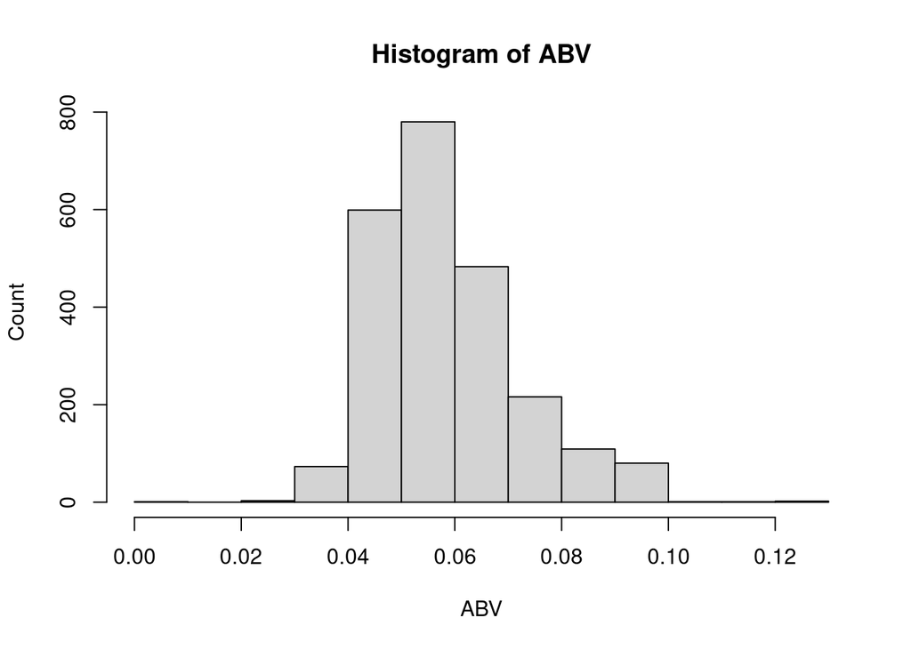

```r
hist(hello_merge$ABV,main = "Histogram of ABV",xlab = "ABV", ylab = "Count")
```

7. Is there an apparent relationship between the bitterness of the beer and its alcoholic content? Draw a scatter plot. Make your best judgment of a relationship and EXPLAIN your answer.

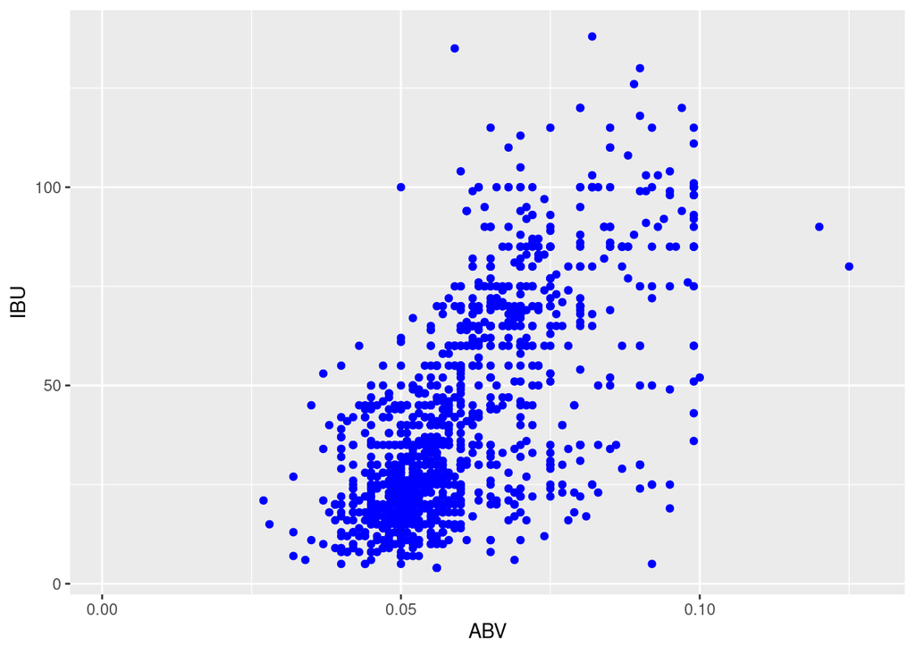

```r
library(ggplot2)
hello_merge %>% ggplot(aes(x = ABV, y = IBU)) +
geom_point(color = "blue")
```

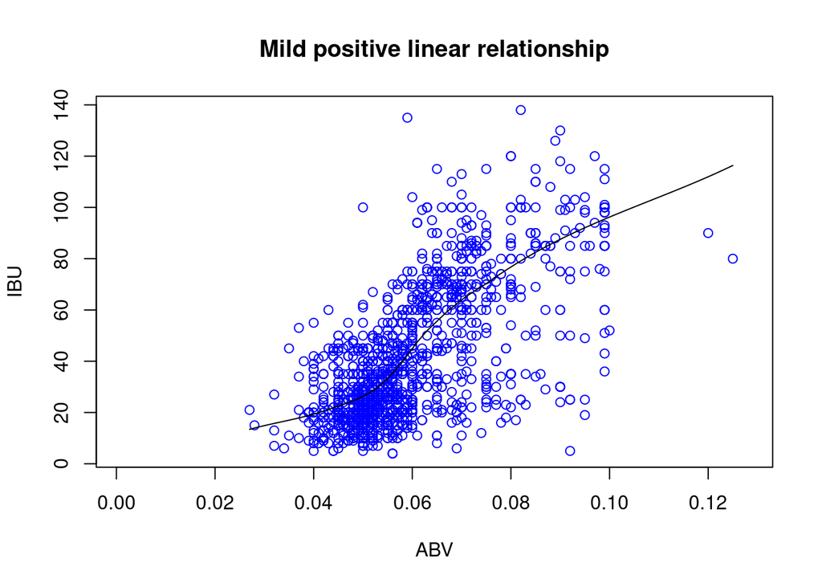

```r
scatter.smooth(x=hello_merge$ABV, y=hello_merge$IBU, main = "Mild positive linear relationship",xlab = "ABV", ylab = "IBU", col="blue")
```

```r
print("This data shows mild positive linear relationship between bitterness and alcoholic content(3rd degree polynomial). Most of Beer bitterness comes from hops. ")
```

```
## [1] "This data shows mild positive linear relationship between bitterness and alcoholic content(3rd degree polynomial). Most of Beer bitterness comes from hops. "
```

8. Budweiser would also like to investigate the difference with respect to IBU and ABV between IPAs (India Pale Ales) and other types of Ale (any beer with “Ale” in its name other than IPA). You decide to use KNN classification to investigate this relationship. Provide statistical evidence one way or the other. You can of course assume your audience is comfortable with percentages … KNN is very easy to understand conceptually. In addition, while you have decided to use KNN to investigate this relationship (KNN is required) you may also feel free to supplement your response to this question with any other methods or techniques you have learned. Creativity and alternative solutions are always encouraged.

```r
library(XML) #xml_Parse
library(dplyr)
library(tidyr)
library(stringi)
library(rvest) #html_table, html_node
library(ggplot2)
library(RCurl) #getURL
library(class)
library(caret)
library(e1071)
#install.packages("Hmisc")
library(Hmisc)
#install.packages("stringr")     # Install & load stringr package
library("stringr")
library(naniar)

#classfy IPAs or not, using IBU and ABV values.
#make new column as IPAs and the values will be 1 or 0. When the Style has "IPA", the value will be 1. nor 0.
hello_IPA <- 1*str_detect(hello_merge$Style, "IPA")
hello_IPA
```

[output not shown]

[output cut: 51 more lines]

```r
hello_merge$IPAs <- hello_IPA
head(hello_merge)
```

```
##   Brew_ID             Name.x        City State        Name.y Beer_ID   ABV IBU
## 1       1 NorthGate Brewing  Minneapolis    MN       Pumpion    2689 0.060  38
## 2       1 NorthGate Brewing  Minneapolis    MN    Stronghold    2688 0.060  25
## 3       1 NorthGate Brewing  Minneapolis    MN   Parapet ESB    2687 0.056  47
## 4       1 NorthGate Brewing  Minneapolis    MN  Get Together    2692 0.045  50
## 5       1 NorthGate Brewing  Minneapolis    MN Maggie's Leap    2691 0.049  26
## 6       1 NorthGate Brewing  Minneapolis    MN    Wall's End    2690 0.048  19
##                                 Style Ounces IPAs
## 1                         Pumpkin Ale     16    0
## 2                     American Porter     16    0
## 3 Extra Special / Strong Bitter (ESB)     16    0
## 4                        American IPA     16    1
## 5                  Milk / Sweet Stout     16    0
## 6                   English Brown Ale     16    0
```

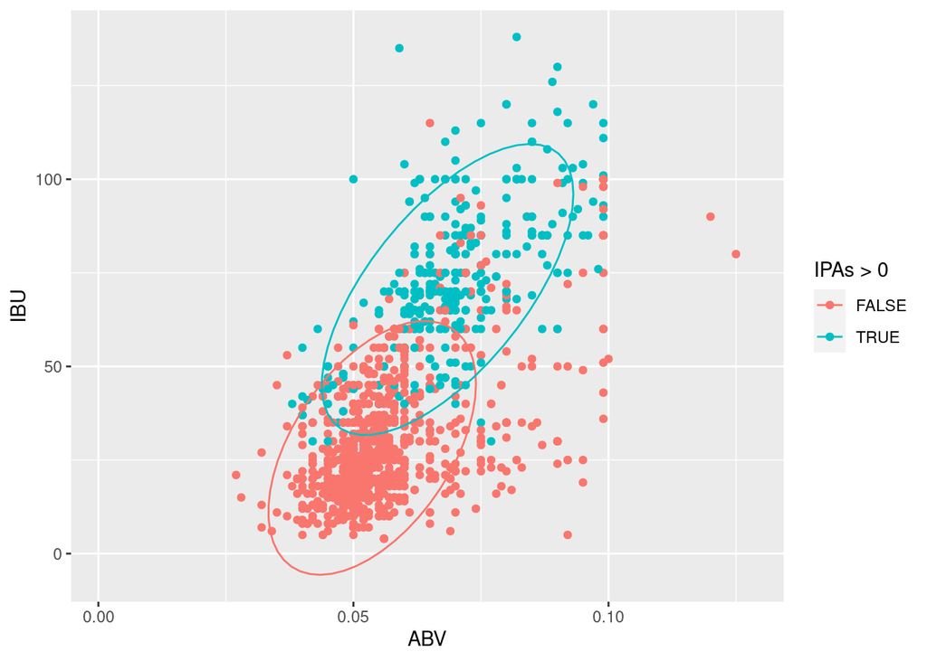

```r
hello_merge %>% ggplot(aes(x = ABV, y = IBU, color=IPAs > 0)) +
geom_point() +
stat_ellipse()
```

```r
#median IPA
hello_filter1=filter(hello_merge, IPAs == "1")
median(hello_filter1$ABV[which(!is.na(hello_filter1$ABV))])
```

```
## [1] 0.068
```

```r
median(hello_filter1$IBU[which(!is.na(hello_filter1$IBU))])
```

```
## [1] 70
```

```r
#median no IPA
hello_filter0=filter(hello_merge, IPAs == "0")
median(hello_filter0$ABV[which(!is.na(hello_filter0$ABV))])
```

```
## [1] 0.054
```

```r
median(hello_filter0$IBU[which(!is.na(hello_filter0$IBU))])
```

```
## [1] 27
```

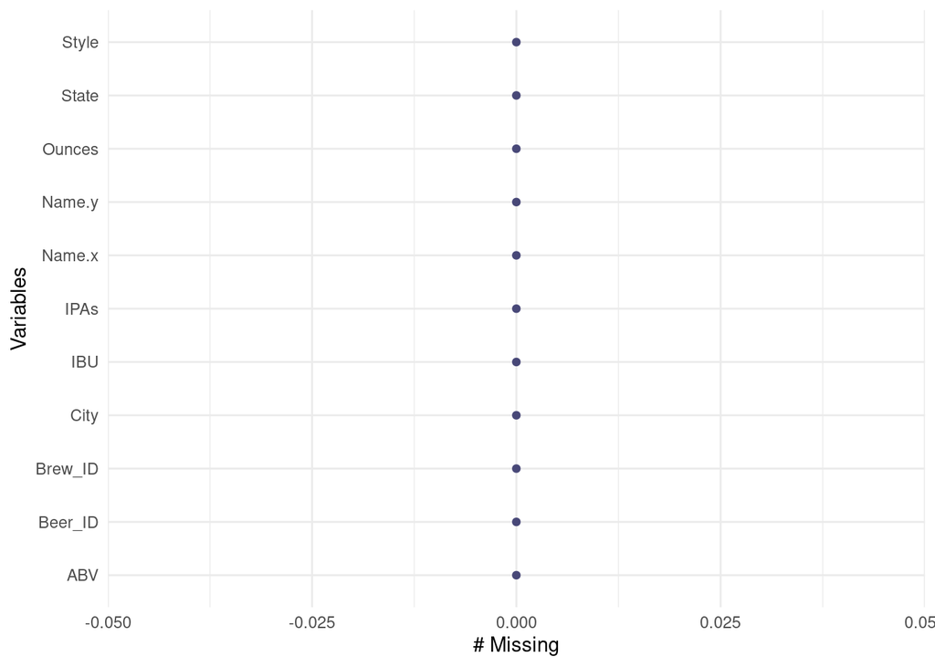

```r
#impute missing values with median
hello_impute <- hello_merge
hello_impute$IBU <- impute(hello_impute$IBU, median)
hello_impute$ABV <- impute(hello_impute$ABV, median)
hello_impute = hello_impute[complete.cases(hello_impute),]
gg_miss_var(hello_impute)
```

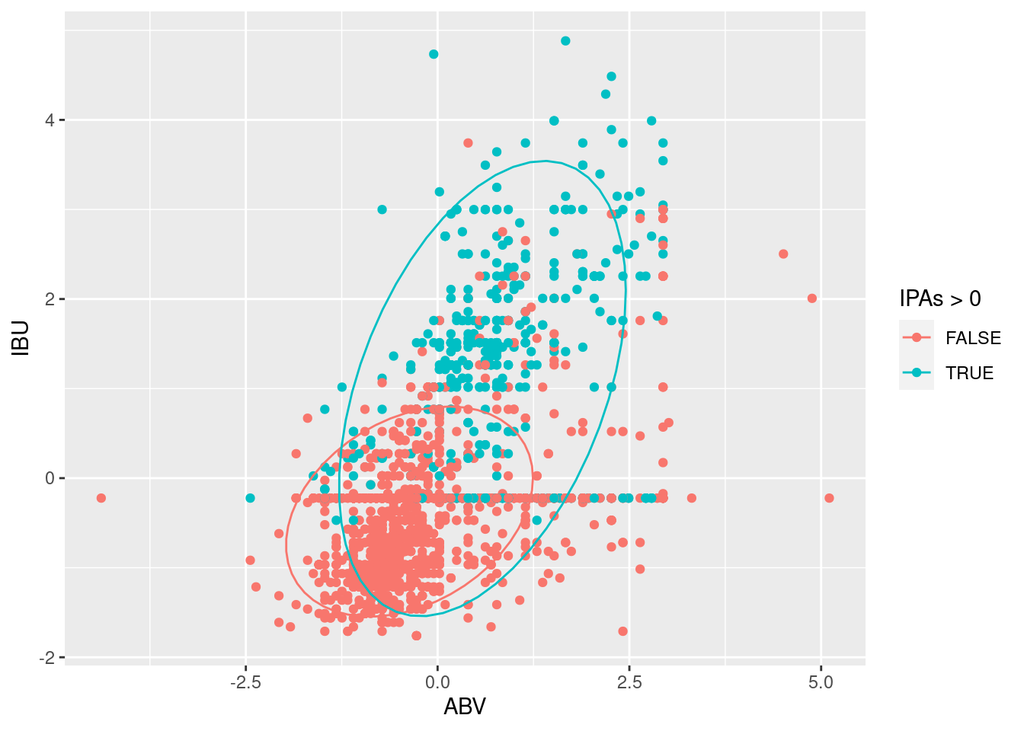

```r
#scaling
hello_scale = hello_impute
hello_scale$IBU = scale(hello_impute$IBU)
hello_scale$ABV = scale(hello_impute$ABV)
hello_scale %>% ggplot(aes(x = ABV, y = IBU, color=IPAs > 0)) +
geom_point() +
stat_ellipse()
```

```r
#could not find function "impute.knn"
#install.packages("imputeTS")
#library(imputeTS)
#impute.knn(hello_merge ,k = 10, rowmax = 0.5, colmax = 0.8, maxp = 1500, rng.seed=362436069)
```

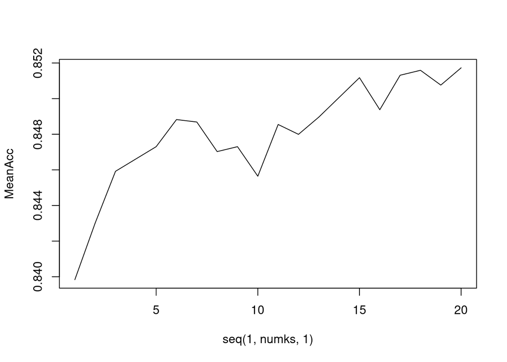

```r
#70/30 training/
# Loop for many k and the average of many training / test partition

set.seed(1)
iterations = 10
numks = 20
splitPerc = .70

masterAcc = matrix(nrow = iterations, ncol = numks)


for(j in 1:iterations)
{
  trainIndices = sample(1:dim(hello_scale)[1],round(splitPerc * dim(hello_scale)[1]))
  train = hello_scale[trainIndices,]
  test = hello_scale[-trainIndices,]
  for(i in 1:numks)
  {
    classifications = knn(train[,c(7,8)],test[,c(7,8)],train$IPAs, prob = TRUE, k = i)
    table(classifications,test$IPAs)
    CM = confusionMatrix(table(classifications,test$IPAs))
    masterAcc[j,i] = CM$overall[1]
  }

}

MeanAcc = colMeans(masterAcc)

plot(seq(1,numks,1),MeanAcc, type = "l")
```

```r
which.max(MeanAcc)
```

```
## [1] 20
```

```r
max(MeanAcc)
```

```
## [1] 0.8517289
```

```r
## Accuracy was used to select the optimal model using the largest value.
## The final value used for the model was k = 20.
classifications = knn(train[,c(7,8)],test[,c(7,8)],train$IPAs, prob = TRUE, k = 5)
table(classifications,test$IPAs)
```

```
##
## classifications   0   1
##               0 493  78
##               1  47 105
```

```r
CM = confusionMatrix(table(classifications,test$IPAs))
```

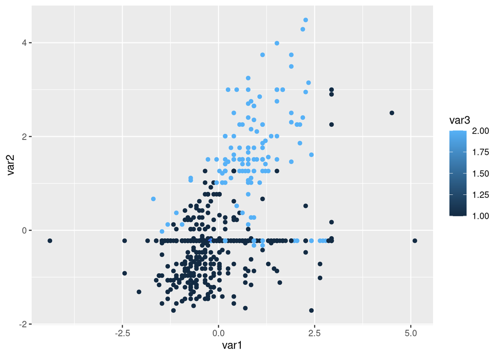

```r
#decision boundary
prob1 <- attr(classifications, "prob")
px1 <- test$ABV
px2 <- test$IBU


mat = matrix(, nrow = 723, ncol = 3)
mat[,1] <- px1
mat[,2] <- px2
mat[,3] <- classifications

dff <- data.frame(mat)
colnames(dff) <- c('var1', 'var2', 'var3')

ggplot(dff)+geom_point(aes(x = var1, y = var2, col=var3))+
geom_contour(aes(x = var1, y = var2, z = var3))
```

#plot when prob1 = 1

[output not shown]

[figure not shown]

```r
#top three
hello_market <- hello_merge %>% group_by(Name.x)%>%tally(sort = TRUE)
hello_market
```

```
## # A tibble: 551 × 2
##    Name.x                         n
##    <chr>                      <int>
##  1 Brewery Vivant                62
##  2 Oskar Blues Brewery           46
##  3 Sun King Brewing Company      38
##  4 Cigar City Brewing Company    25
##  5 Sixpoint Craft Ales           24
##  6 Hopworks Urban Brewery        23
##  7 Stevens Point Brewery         22
##  8 21st Amendment Brewery        20
##  9 Great Crescent Brewery        20
## 10 Bonfire Brewing Company       19
## # … with 541 more rows
```